```python
!python --version
```

```
Python 3.11.2
```

# Module 1 - Basics of programming using Python

# 1. Input and output

## 1.1 Output

```python
# Print output

print('Hello', 'world', '!')

print("Hello world!")

print('Hello \nworld\n!')
```

```
Hello world !
Hello world!
Hello
world
!
```

## 1.2 Input

```python
# Read input

x = int(input('Enter a number:'))

y = int(input('Enter a number:'))

print(x, y)

z = x + y

print("Sum of x and y are:", z)
```

```
2 3
Sum of x and y are: 5
```

# 2. Data types and variables

## 2.1 Variables

#### Variables allow programs to refer to values using names rather than memory locations. Ex: city refers to a person's city, and name refers to a person's name.

```python
city = 'Auckland'
print(city)

name = 'Laks'
print(name)
```

```
Auckland
Laks
```

## 2.2 Variable naming rules

- A variable name can consist of letters, digits, and underscores and be of any length,
- The name cannot start with a digit,
- Letter case matters, example name is different from Name,
- Python has reserved words, known as keywords, which have special functions and cannot be used as names for variables (or other objects).

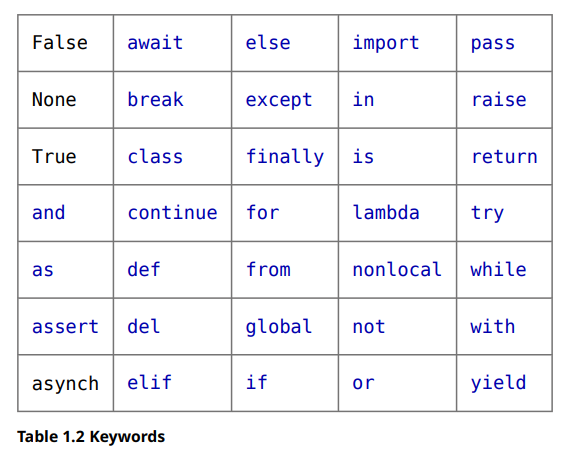

##### **Best practices for variable naming convention:**

- A name should be short and descriptive, so words are preferred over single characters in programs for readability, example count is better than c.

## 2.3 Data types

#### Common data types are -

##### Integer: any number in the range of -2147483648 through +2147483647, example 1, -1

```python
x = int()
y = int()

print(type(x), type(y))

x = int(1.5)
y = int(1)

print(x+y)
```

```
<class 'int'> <class 'int'>
2
```

##### Float: the range of float values is approximately 1.7e-308 to 1.7e+308, example 1.5, -1.5

```python
x = float()
y = float()

print(type(x), type(y))

x = float(1.5)
y = float(1)

print(x+y)
```

```
<class 'float'> <class 'float'>
2.5
```

##### String: characters or collection of characters, example L, Laks, This is a longer string

```python
str1 = "Hello"
str2 = "world!"
print(str1, str2)
```

```
Hello world!
```

```python
str(1)
```

[output not shown]

##### Boolean: Logical value, only two values - True or False

```python
a = 1
b = 2

print(a == b)
print(1 == 1)
print(1 > 2)
```

```
False
True
False
```

```python
print(bool(0))
print(bool(1))
```

```
False
True
```

# 3. Data structures

## 3.1 Lists: collection of elements of same or different data types

```python
lst = []
print(lst)
```

```
[]
```

#### Append: add items to the list incrementally

```python
lst.append(1)
lst.append('A')
lst
```

```
[1, 'A']
```

##### Pop and remove: delete elements from list

```python
lst.pop()
lst
```

```
[1]
```

```python
lst.remove(1)
lst
```

```
[]
```

##### Extend: add all the elements of lst2 on to the end of lst

```python
lst1 = [1, 'A']
lst2 = [2, 'B']

print("Before:")
print(lst1)
print(lst2)

lst1.extend(lst2)

print("After:")
print(lst1)
print(lst2)
```

[output not shown]

```python
print(lst1 + lst2)
```

[output not shown]

##### Insert and copy

```python
lst1.insert(5, 3)

print(lst1)
```

[output not shown]

```python
lst3 = lst1.copy()

print(lst3)
```

[output not shown]

##### Other operations on list

```python
num_lst = [0, 99, 56, 45]

# minimum
print('Min: ', min(num_lst))

# maximum
print('Max: ', max(num_lst))

# sum
print('Sum: ', sum(num_lst))

# slice
print("\n Indexing and slicing:")
print("All: ", num_lst[:])
print("First: ", num_lst[0])
print("Last: ", num_lst[-1])
print("First two: ", num_lst[:2])
print("All except last element: ", num_lst[:-1])
print("Reverse order: ", num_lst[::-1])
```

```
Min:  0
Max:  99
Sum:  200

 Indexing and slicing:
All:  [0, 99, 56, 45]
First:  0
Last:  45
First two:  [0, 99]
All except last element:  [0, 99, 56]
Reverse order:  [45, 56, 99, 0]
```

## 3.2 Tuple: tuple is similar to list but immutable

```python
tup = (1, 'a', 2, 'b')

type(tup)
```

```
tuple
```

```python
tup[0]
```

```
1
```

```python
tup[0] = 0
```

```
---------------------------------------------------------------------------
TypeError                                 Traceback (most recent call last)
Cell In[106], line 1
----> 1 tup[0] = 0

TypeError: 'tuple' object does not support item assignment
```

## 3.3 Set: set() method is used to convert any of the iterable to a sequence of iterable elements with distinct elements

```python
s = set()
type(s)
```

```
set
```

```python
print(num_lst)

set(num_lst)
```

```
[0, 99, 56, 45]
```

```
{0, 45, 56, 99}
```

```python
num_lst = [0, -1, 0, -2, 0]

set(num_lst)
```

```
{-2, -1, 0}
```

## 3.4 Dict: key-value pairs

```python
d = {}
type(d)
```

```
dict
```

```python
d['ca'] = 'California'
d['ok'] = 'Oklahoma'
d['nj'] = 'New Jersey'
d['tx'] = 'Texas'
```

```python
len(d)
```

```
4
```

```python
d.keys()
```

```
dict_keys(['ca', 'ok', 'nj', 'tx'])
```

```python
d.values()
```

```
dict_values(['California', 'Oklahoma', 'New Jersey', 'Texas'])
```

```python
d.items()
```

```
dict_items([('ca', 'California'), ('ok', 'Oklahoma'), ('nj', 'New Jersey'), ('tx', 'Texas')])
```

```python
d.get('ca')
```

```
'California'
```

# 4. Arithmetic and logical operations

## 4.1 Arithmetic operations

##### Addition

```python
1 + 1
```

```
2
```

##### Subtraction

```python
1 - 1
```

```
0
```

##### Division

```python
1 / 1
```

```
1.0
```

```python
1 // 1
```

```
1
```

##### Multiplication

```python
1 * 3
```

```
3
```

##### Modulo

```python
1 % 2
```

```
1
```

##### Exponentiation

```python
2 ** 2
```

```
4
```

##### Precedence

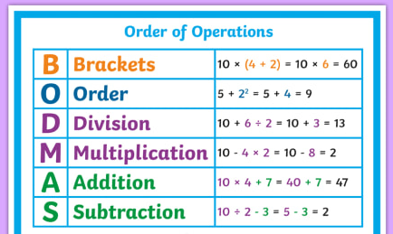

```python
'''
Expression: 14 - (2 * 2**2 + 5)

Step 1: 14 - (2 * 4 + 5)

Step 2: 14 - (8 + 5)

Step 3: 14 - 13

'''

14 - (2 * 2**2 + 5)
```

```
1
```

Inequality, and equal

```python
1 > 2
```

```
False
```

```python
1 == 2
```

```
False
```

```python
1 < 2
```

```
True
```

```python
1 != 2
```

```
True
```

## 4.2 Logical operations

And

```python
(1 == 1) and (1 == 0)
```

[output not shown]

```python
(1 == 1) and (1 == 1)
```

[output not shown]

Or

```python
(1 == 1) or (1 == 0)
```

[output not shown]

```python
(1 == 0) or (1 == 2)
```

[output not shown]

Not

```python
not(True)
```

[output not shown]

```python
not(False)
```

[output not shown]

```python
not(0)
```

[output not shown]

```python
not(1)
```

[output not shown]

# 5. Conditional and iterative constructs

## 5.1 Conditional construct

```python
x = 0.5; y = 1

if x == y:
    print('x and y are the same.')
elif x > y:
    print('x is bigger than y.')
else:
    print('x is smaller than y.')
```

```
x is smaller than y.
```

## 5.2 Iterative construct

### 5.2.1 for loop

```python
num_list = range(0, 11)

for n in num_list:
    print(n)
```

[output not shown]

### 5.2.2 while loop

```python
n = 0

while n < 11:
    print(n)
    n = n + 1
```

[output not shown]

# 6. Functions

Organise code into smaller chunks that are part of a larger program.

##### Write a function to perform basic arithmetic operations

```python
def math(x, y):
    ''' function to take two numbers as inputs and print the basic math operations'''
    print("x:", x, "y:", y)
    print("The sum of x and y is:", x + y)
    print("The difference of x and y is:", x - y)
    print("The product of x and y is:", x * y)
    print("The division of x and y is:", x / y)
```

```python
x = int(input("Enter a number:"))
y = int(input("Enter a number:"))

math(x, y)
```

```
x: 1 y: 2
The sum of x and y is: 3
The difference of x and y is: -1
The product of x and y is: 2
The division of x and y is: 0.5
```

##### Write a function to reverse the string

```python
def rev_string(str):
    ''' function to take a string as input, reverse the string and return'''
    return(str[::-1])
```

```python
text = 'The quick brown fox jumps over the lazy dog'

rev_string(text)
```

```
'god yzal eht revo spmuj xof nworb kciuq ehT'
```